# When did growth begin? New estimates of productivity growth in England from 1250 to 1870 *Quarterly Journal of Economics* 2025 (Volume 140), Issue 2

Paul Boucasse, Emi Nakamura, Jon Steinsson

Author

Seiro Ito

Published

June 02, 2026, 13:06 +0900

doi.org/10.1093/qje/qjae046

## Summary

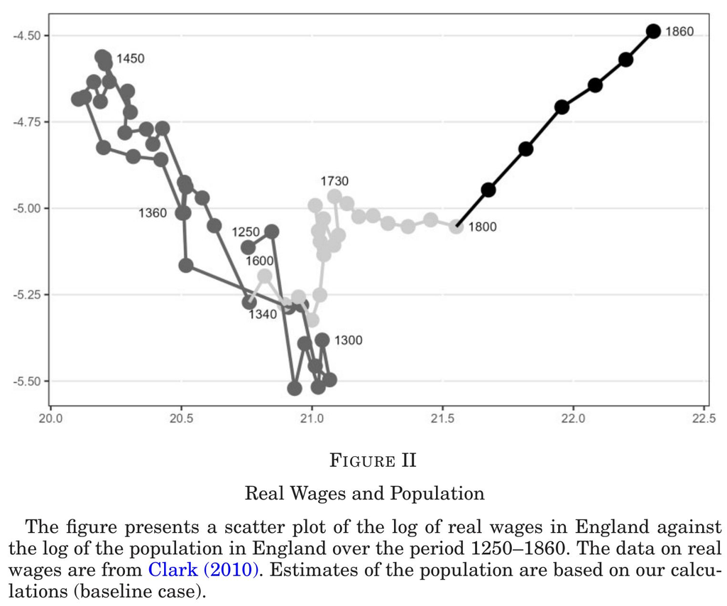

Figure 1: Population and real wage

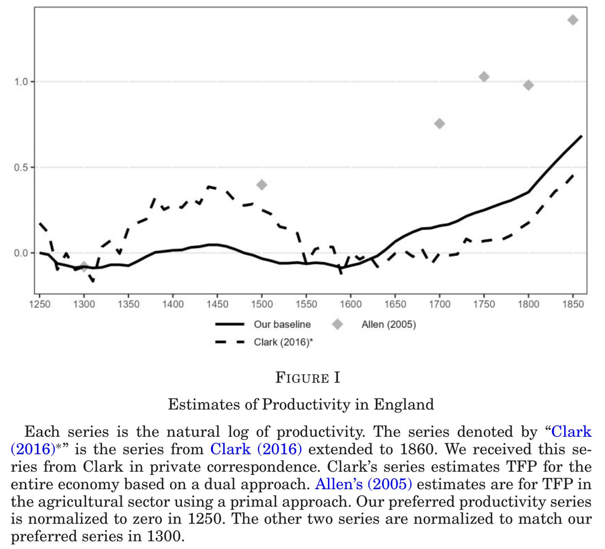

Figure 2: TFP

- Growth = Industrial Revolution began in 1600’s

  | period | growth |
  | --- | --- |
  | - 1600 | 0% |
  | 1600 - 1810 | 2% |
  | 1810 - | 5% |

  - Not after the Glorious Revolution, as argued in the literature
  - Predates 100 years from the Glorious Revolution
- A new series of TFP (1250-) is computed by combining existing data, a labour demand function, and Black Death as an exogenous population shock
- Increased TFP growth may be due to:
  - Reformation 宗教改革
  - decline of feudalism
  - rise of yeoman
  - movable type printing and increase in literacy
  - international trade
- Post Industrial Revolution (1810-) growth is explained by release from fixed land constraint (steam engines) and increased days worked

# Research design

**ImportantVariable definitions**

| Category | Symbol | Definition / Description |
| --- | --- | --- |
| **Observed Data & State Variables** | $w_t$ | Log of real wages |
|  | $l_t$ | Log of total labor supply |
|  | $n_t$ | Log of the population |
|  | $d_t$ | Log of days worked per worker per year |
|  | $k_t$ | Log of the capital stock |
|  | $s_t$ | Log of the rental price of land |
|  | $r_t$ | Rental rate for capital *(Note: kept as a rate, appears in equations as $\log(r_t + \delta)$)* |
|  | $Z$ | Fixed quantity of land *(Appears in equations as $\log Z$)* |
| **Productivity Measures** | $a_t$ | Log of Total Factor Productivity (TFP) |
|  | $\tilde{a}_t$ | Permanent (random-walk) component of TFP |
|  | $m_t$ | Log of the Malmquist productivity index *(Accounts for structural change when $\alpha_t, \beta_t$ vary)* |
|  | $\tilde{m}_t$ | Permanent component of the Malmquist productivity index |
|  | $\bar{w}$ | Theoretical steady-state real wage *(Derived from the Malthusian model)* |
|  | $\hat{x}_t$ | Difference/growth from the previous period *(i.e., $x_t - x_{t-1}$)* |
|  | $\bar{x}_t$ | Average of the current and previous period *(i.e., $\frac{x_{t-1} + x_t}{2}$)* |
| **Structural Parameters** | $\alpha, \alpha_t$ | Elasticity of output with respect to land *(Represents slope of labor demand in the simple model)* |
|  | $\beta, \beta_t$ | Elasticity of output with respect to capital *(Note: $1 - \alpha - \beta$ equals labor elasticity)* |
|  | $\delta$ | Rate of depreciation of capital |
|  | $\lambda$ | Log of the labor scaling constant $\Lambda$ *(Maps population and days worked into total labor force)* |
|  | $\mu$ | Average growth rate of productivity *(Drift parameter in the random walk process)* |
|  | $\gamma$ | Elasticity of population growth to real income *(Represents the “Malthusian population force”)* |
|  | $\phi, \phi_t, \tilde{\phi}$ | Constant terms aggregating structural parameters, fixed land ($Z$), and the labor scaling constant ($\lambda$) |
|  | $\omega$ | Constant drift term in the population growth equation |
| **Shocks & Error Processes** | $\epsilon_{1t}$ | Permanent productivity shock *(Innovation to the random walk of $\tilde{a}_t$ or $\tilde{m}_t$)* |
|  | $\epsilon_{2t}$ | Transitory productivity shock *(Captures weather variations, short-term noise, etc.)* |
|  | $\xi_t$ | Total exogenous shock to population growth |
|  | $\xi_{1t}$ | “Plague” shock *(Rare, large negative shock modeled via mixture distribution)* |
|  | $\xi_{2t}$ | Normal/transitory exogenous population shock |
|  | $\sigma_{\epsilon_1}^2, \sigma_{\epsilon_2}^2, \sigma_{\xi_2}^2$ | Variances of their respective independent normal distributions |
|  | $\iota_t$ | Measurement errors mapping true unobserved variables to noisy observed data *(e.g., $\iota_t^d$ for days, $\iota_t^r$ for rates)* |

**ImportantModel and data**

**1. The Simple Model (Section II)**

- **Used for:** Table I, Figure V, Figure VI
- **Data:** Real wages ($w_t$), Population ($l_t$)
- **Equations:**
  - $a_t = w_t + \alpha l_t - \phi$ (from 1)
  - $a_t = \tilde{a}_t + \epsilon_{2t}$ (6)
  - $\tilde{a}_t = \mu + \tilde{a}_{t-1} + \epsilon_{1t}$ (2)
- **Plots/Estimates:**
  - **Table I:** Estimates average growth $\mu$.
  - **Figure V:** Plots posterior probability of structural breaks in $\mu$.
  - **Figure VI:** Plots the permanent component $\tilde{a}_t$.
- **Assumptions:** $\epsilon_{1t} \sim \mathcal N(0, \sigma_{\epsilon_1}^2)$ and $\epsilon_{2t} \sim \mathcal N(0, \sigma_{\epsilon_2}^2)$ are assumed independent over time.

**2. Full Malthusian Model: Constant $\alpha, \beta$ (Section III.A)**

- **Used for:** Table IV (“Constant $\alpha, \beta$”), Figure X (“Constant $\alpha, \beta$”)
- **Data:** Real wages ($w_t$), Population ($n_t$), Days worked ($d_t$), Rates of return ($r_t$)
- **Equations:**
  - $a_t = (1-\beta)(w_t - \tilde{\phi}) + \alpha(d_t + n_t) + \beta \log(r_t + \delta)$ (from 8)
  - $a_t = \tilde{a}_t + \epsilon_{2t}$ (6)
  - $\tilde{a}_t = \mu + \tilde{a}_{t-1} + \epsilon_{1t}$ (7)
  - $n_t - n_{t-1} = \omega + \gamma(w_{t-1} + d_{t-1}) + \xi_t$ (9)
  - $\xi_t = \xi_{1t} + \xi_{2t}$ (10)
- **Plots/Estimates:** $\mu$ (Table IV), $\tilde{a}_t$ (Figure X).
- **Assumptions:** $\epsilon_{1t}$ and $\epsilon_{2t}$ are assumed independent. Population shocks consist of a rare plague mixture shock $\xi_{1t}$ (11) and a normal shock $\xi_{2t} \sim \mathcal N(0, \sigma_{\xi_2}^2)$, which are assumed independent.

**3. Early Industrial Economy: Time-Varying $\alpha_t, \beta_t$ (Section III.B)**

- **Used for:** Table IV (“Baseline”), Table V, Figure I, Figure X (“Baseline”), Figure XI, Figure XIII, Figure XVI, Figure XVII
- **Data:** $w_t$, $n_t$, $d_t$, $r_t$, Capital stock ($k_t$), Land rents ($s_t$)
- **Equations:**
  - $\alpha_t, \beta_t$ are pinned down by land and capital demand:
    - $s_t = w_t + n_t + d_t - \log Z + \log \alpha_t - \log(1 - \alpha_t - \beta_t) + \lambda$ (15)
    - $\log(r_t + \delta) = w_t + n_t + d_t - k_t + \log \beta_t - \log(1 - \alpha_t - \beta_t) + \lambda$ (16)
  - $a_t$ is extracted via labor demand:
    - $w_t = \phi_t + \frac{1}{1-\beta_t}a_t - \frac{\alpha_t}{1-\beta_t}(d_t + n_t) - \frac{\beta_t}{1-\beta_t}\log(r_t + \delta)$ (13)
  - Converted to Malmquist productivity index ($m_t$) to account for structural change:
    - $\hat{m}_t = \hat{a}_t + \hat{\alpha}_t \log Z + \hat{\beta}_t \bar{k}_t - (\hat{\alpha}_t + \hat{\beta}_t)(\bar{d}_t + \bar{n}_t + \lambda)$ (18)
  - $m_t = \tilde{m}_t + \epsilon_{2t}$ (19)
  - $\tilde{m}_t = \mu + \tilde{m}_{t-1} + \epsilon_{1t}$ (20)
  - Population dynamics follow (9) and (10) as above.
- **Plots/Estimates:**
  - **Table IV:** Estimates $\mu$.
  - **Table V:** Estimates population income elasticity $\gamma$.
  - **Figure I, Figure X, Figure XIII:** Plots the permanent component $\tilde{m}_t$ ($\tilde{a}_t$).
  - **Figure XI:** Plots extracted structural parameters $\alpha_t, \beta_t$.
  - **Figure XVI:** Plots $n_t$ simulated iteratively forward using (9) with shocks set to zero.
  - **Figure XVII:** Plots $n_t$ estimated from the state-space model incorporating shock processes (10) and (11).
- **Assumptions:** Independence is assumed between $\epsilon_1, \epsilon_2$ and between $\xi_1, \xi_2$. Factor share simplex ($\alpha_t, \beta_t, 1-\alpha_t-\beta_t$) is assumed to follow a Dirichlet prior distribution to discipline structural change after 1760. Input data assumed measured with independent error processes ($\iota_t$).

**4. Steady-State Analytics (Section V)**

- **Used for:** Figure XIV, Figure XV
- **Data:** $w_t$, $d_t$ (as well as posterior parameters from Section III.B)
- **Equations:**
  - $\bar{w} = \frac{\mu}{\alpha \gamma} + \text{constant}$ (21)
- **Plots/Estimates:**
  - **Figure XIV:** Plots the theoretical $\bar{w}$ mapping across different values of $\alpha$ and $\mu$.
  - **Figure XV:** Plots the ratio of theoretical steady-state wage $\bar{w}$ derived via (21) against the actual data $w_t$.

**5. Pure Data / No Structural Model Applied**

- **Used for:** Table II, Table III, Figure II, Figure III, Figure IV, Figure VIII, Figure IX, Figure XII.
- **Methodology:** These display raw historical input data, simple transformations (scatter plots), or statistical priors (Table III). No structural equations or error processes are applied.

## Simplest method

**Data**

Land, real wage[^1], population[^2] [^3]

<sup>1</sup> Clark (2010)

———. 2010. “The Macroeconomic Aggregates for England 1209–1869.” *Research in Economic History* 27: 51–140. https://doi.org/10.1108/S0363-3268(2010)0000027004.

———. 2007. “The Long March of History: Farm Wages, Population, and Economic Growth, England 1209–1869.” *Economic History Review* 60: 97–135. https://doi.org/10.1111/j.1468-0289.2006.00358.x.

Wrigley, E. A., R. S. Davies, J. E. Oeppen, and R. S. Schofield. 1997. *English Population History from Family Reconstruction, 1580–1837*. Cambridge: Cambridge University Press.

<sup>3</sup> Measurement errors in observed population $n_t$ with true population $\tilde{n}_t$
$$n_t = \psi + \tilde{n}_t + \iota_t^n$$
$$\iota_t^n \sim t_{\nu_n}(0, \sigma_n^2)$$

**CD production**

$Y_{t}=A_{t}Z^{\alpha}L^{1-\alpha}_{t}$ →FOC→ $w_{t}=\phi+a_{t}-\alpha l_{t}$, $\phi = \ln(1 - \alpha) + \alpha \ln Z$[^4]

<sup>4</sup> Assume: Fixed supply of labour ($\propto$ population)

**Identification of $\alpha$**

$\alpha=\frac{\Delta W_{t}}{\Delta L_{t}}$ before/after Black Death→$\hat{\alpha}=.7$

**Backing out TFP**

$\hat{a}_{t}=w_{t}-\hat{\phi}+\hat{\alpha} l_{t}$

**Separate permanent and transitory TFP by Brownian motion with drift**

$\tilde{a}_t = \mu + \tilde{a}_{t-1} + \epsilon_{1t}$

**Normalisation equation for real wages**

$w_t = \phi^w + \tilde{w}_t \quad \text{where} \quad \phi^w \sim \mathcal N(0, 100^2)$

**Structural break in $\mu$**

Separating to 3 periods, data suggests break years at 1600, 1810

## A fixed elasticity Malthusian model

Merit: Capital is incorporated

Add

**Data**

Interest rate (rent charges on collaterallised loans), days worked[^5]

<sup>5</sup> From Humphries and Weisdorf (2019)

Humphries, Jane, and Jacob Weisdorf. 2019. “Unreal Wages? Real Income and Economic Growth in England, 1260–1850.” *Economic Journal* 129: 2867–87. https://doi.org/10.1093/ej/uez017.

**Production function and optimisation**

$Y_t = A_t Z^\alpha K_t^\beta L_t^{1-\alpha-\beta}$ →FOCs→ $w_t = \phi + \frac{1}{1-\beta} a_t - \frac{\alpha}{1-\beta} (d_t + n_t) - \frac{\beta}{1-\beta} \ln(r_t + \delta)$[^6]

<sup>6</sup> More general prod func: $Y_t = A_t F(Z,L_t,K_t)$ →FOCs and ln linearise→ $w_t \approx \tilde{\varphi} + (1+\tilde{\beta})a_t - \tilde{\alpha}\ell_t - \tilde{\beta}\ln(r_t+\delta)$ with $\tilde{\alpha} = -\frac{L}{F_LF_{KK}}\!\left(F_{LL}F_{KK}-F_{LK}^2\right), \tilde{\beta} = -\frac{F_KF_{LK}}{F_LF_{KK}}$

**Malthusian population dynamics**

$n_t - n_{t-1} = \omega + \gamma(w_{t-1} + d_{t-1}) + \xi_t$

**Measurement equation**

$r_t = \tilde{r}_{it} + \iota_{it}^r \quad \text{where} \quad \iota_{it}^r \sim t_{\nu_{ir}}(0, \tilde{\sigma}_{ir}^2)$ for $i$= interest rates, land rents, if no interest rates or land rents, $r_t \sim \mathcal N_{(0,.2)}(r_{t-1}, 0.01^2)$

## A varying elasticity Malthusian model

Merit: Structural change (elasticity change) is incorporated

Add

**Data**

Net capital stock[^7], land rents $S_{t}$[^8]

<sup>7</sup> From Feinstein (1988)

Feinstein, Charles H. 1988. “National Statistics, 1760–1920.” In *Studies in Capital Formation in the United Kingdom, 1750–1920*, edited by Charles H. Feinstein and S. Pollard, 259–471. Oxford: Clarendon Press.

<sup>8</sup> From Clark (2002)

Clark, Gregory. 2002. “Land Rental Values and the Agrarian Economy: England and Wales, 1500–1914.” *European Review of Economic History* 6: 281–308. https://doi.org/10.1017/S136149160200014X.

**3 factor CD production**

$Y_t = A_t Z^{\alpha_t} K_t^{\beta_t} L_t^{1-\alpha_t-\beta_t}$ →FOCs→ $s_t = w_t + n_t + d_t - \ln Z + \ln \alpha_t - \ln(1 - \alpha_t - \beta_t) + \lambda$, $\ln(r_t + \delta) = w_t + n_t + d_t - k_t + \ln \beta_t - \ln(1 - \alpha_t - \beta_t) + \lambda$ These 2 eqns give $\alpha_{t}, \beta_{t}$

**Malmquist index**

For time-variant production technology $\hat{m}_t = \hat{a}_t + \hat{\alpha}_t \ln Z + \hat{\beta}_t \bar{k}_t - (\hat{\alpha}_t + \hat{\beta}_t)(\bar{d}_t + \bar{n}_t + \lambda)$

**Measurement errors**

$s_t = \tilde{s}_t + \iota_t^s \quad \text{where} \quad \iota_t^s \sim t_{\nu_s}(0, \tilde{\sigma}_s^2)$, $k_t = \tilde{k}_t + \iota_t^k \quad \text{where} \quad \iota_t^k \sim t_{\nu_k}(0, \tilde{\sigma}_k^2)$, $m_t = \tilde{m}_t + \epsilon_{2t} \quad \text{where} \quad \epsilon_{2t} \sim \mathcal N(0, \sigma_{\epsilon_2}^2)$, $\tilde{m}_t = \mu + \tilde{m}_{t-1} + \epsilon_{1t} \quad \text{where} \quad \epsilon_{1t} \sim \mathcal N(0, \sigma_{\epsilon_1}^2)$

**Normalisation equation**

$K_t = \phi^K + \tilde{K}_t \quad \text{where} \quad \phi^K \sim \mathcal N(0, 100^2)$, $S_t = \phi^S + \tilde{S}_t \quad \text{where} \quad \phi^S \sim \mathcal N(0, 100^2)$

## Data issues

- $T=61$ for real wages and population
- $T=10$ (1760-1860) for capital, interest rates, land rents

Despite the power limitations, the only estimate with large $p$ value is

- Table V baseline $\hat\gamma$ = 0.03, CI [−0.06, 0.12] — the Malthusian feedback is imprecisely estimated with fixed days worked

# Bayesian estimation

Table 1

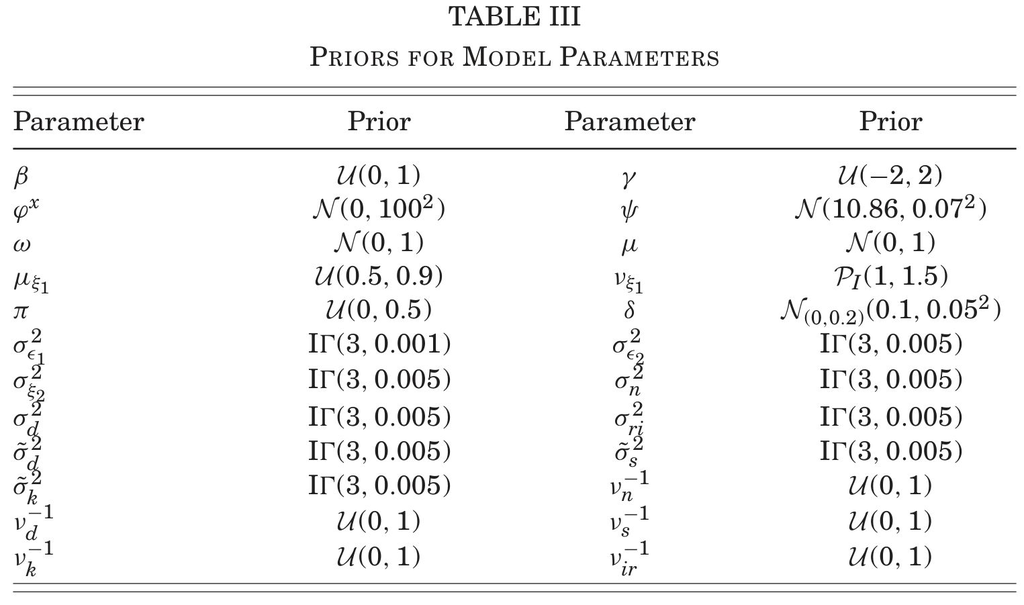

- MCMC (not Gibbs sampling, Hamiltonian MC)
- Assume Dirichlet likelihood for $\alpha_t, \beta_t, 1-\alpha_t - \beta_t$

## $\tilde{a}_{t}$ likelihood

Substitute (6) into (8):
$$w_t = \underbrace{\phi + \frac{1}{1-\beta}\,\tilde{a}_t
- \frac{\alpha}{1-\beta}(d_t+n_t)
- \frac{\beta}{1-\beta}\ln(r_t+\delta)}_{\displaystyle\mu_{w,t}(\tilde{a}_t)}
\;+\; \frac{\varepsilon_{2t}}{1-\beta}$$
Wage conditional likelihood for (8) through transitory shock $\varepsilon_{2t} \sim \mathcal N(0,\sigma_2^2)$
$$w_t \;\Big|\; \tilde{a}_t,\,n_t,\,d_t,\,r_t,\,\alpha,\beta,\phi
\;\sim\;
\mathcal N\left(\mu_{w,t}(\tilde{a}_t),\;
\left[\frac{\sigma_2}{1-\beta}\right]^{\!2}\right)
\tag{$\mathcal{L}_8$}$$
where
$$\mu_{w,t}(\tilde{a}_t) \;\equiv\;
\phi + \frac{\tilde{a}_t}{1-\beta}
- \frac{\alpha}{1-\beta}(d_t+n_t)
- \frac{\beta}{1-\beta}\ln(r_t+\delta)$$
(7) is the state transition for $\tilde{a}_t$. It contributes a separate likelihood factor (state equation) throgh $\varepsilon_{1t} \sim \mathcal N(0,\sigma_1^2)$:
$$\tilde{a}_t \;\Big|\; \tilde{a}_{t-1},\mu,\sigma_1
\;\sim\; \mathcal N(\mu + \tilde{a}_{t-1},\;\sigma_1^2)
\tag{$\mathcal{L}_7$}$$

## $n_{t}$ likelihood

Define the deterministic part of equation (9):
$$\mu_{n,t} \;\equiv\; \omega + \gamma(w_{t-1} + d_{t-1}) + n_{t-1}$$

Then $n_t = \mu_{n,t} + \xi_{1t} + \xi_{2t}$. The noise $\xi_{2t} \sim \mathcal N(0,\sigma_\xi^2)$ makes $n_t$ normal *conditional on* $\xi_{1t}$. The plague shock $\xi_{1t}$ shifts the mean; its occurrence is uncertain.

The plague indicator is not observed. Integrating over plague shock gives a two-component mixture:
$$\begin{align}
p(n_t &\mid w_{t-1},d_{t-1},n_{t-1},\xi_{1t},\pi)\\
& =
\pi\cdot\mathcal N\bigl(n_t;\;\mu_{n,t}+\xi_{1t},\;\sigma_\xi^2\bigr)\\
&\hspace{1em}+ (1-\pi)\cdot\mathcal N\bigl(n_t;\;\mu_{n,t},\;\sigma_\xi^2\bigr)
\tag{$\mathcal L_{9}$}
\end{align}$$
where $\xi_{1t} = \ln(\mathrm{XI1}_t)$ and $\mathrm{XI1}_t \sim \mathrm{Beta}(\beta_1,\beta_2)$.

The plague intensity $\mathrm{XI1}_t$ (fraction of population surviving) is itself a sampled parameter with its own likelihood:
$$\mathrm{XI1}_t \sim \mathrm{Beta}(\beta_1,\beta_2), \qquad
\xi_{1t} = \ln(\mathrm{XI1}_t) \leq 0$$
So log-likelihood is
$$\begin{align}
\ln p(n_t,&\,\mathrm{XI1}_t \mid \cdot)\\
&= \underbrace{\ln\mathrm{Beta}(\mathrm{XI1}_t;\beta_1,\beta_2)}_{\text{plague intensity prior}}\\
&+ \underbrace{\ln\!\left[
\pi\,\phi_{\sigma_\xi}\!\left(n_t - \mu_{n,t} - \xi_{1t}\right)
+ (1-\pi)\,\phi_{\sigma_\xi}\!\left(n_t - \mu_{n,t}\right)
\right]}_{\text{mixture population likelihood}}
\end{align}$$
where $\phi_{\sigma}(\cdot)$ is the $\mathcal N(0,\sigma^2)$ density.
$$\begin{alignat}{2}
\ln L_t &=
&\underbrace{\ln p(\tilde{a}_t \mid \tilde{a}_{t-1})}_{\mathcal{L}_7:\;\text{state eq.}}
&+\underbrace{\ln p(w_t \mid \tilde{a}_t,\ldots)}_{\mathcal{L}_8:\;\text{wage eq.}}\\
&\hspace{1em}+
&\underbrace{\ln p(\mathrm{XI1}_t \mid \beta_1,\beta_2)}_{\text{plague intensity}}
&+\underbrace{\ln p(n_t \mid w_{t-1},n_{t-1},\xi_{1t})}_{\mathcal{L}_9:\;\text{pop. eq.}}
\end{alignat}$$

## Dirichlet likelihood

- Simplex ($\alpha_t, \beta_t, 1-\alpha_t-\beta_t$) is assumed to follow Dirichlet with concentration parameter $c_{s}$
- $c_{s}\times(\alpha_t, \beta_t, 1-\alpha_t-\beta_t) \sim DirMult(\theta|c_{b})$
- $c_{s}=3$ ⇒ mean = first lag

# Results

## Onset

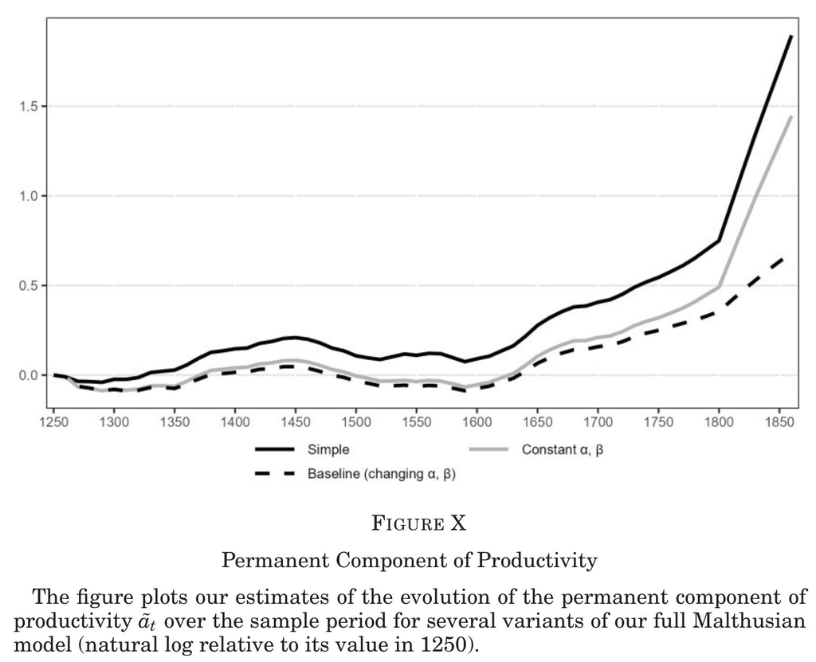

Figure 3: TFP by different methods

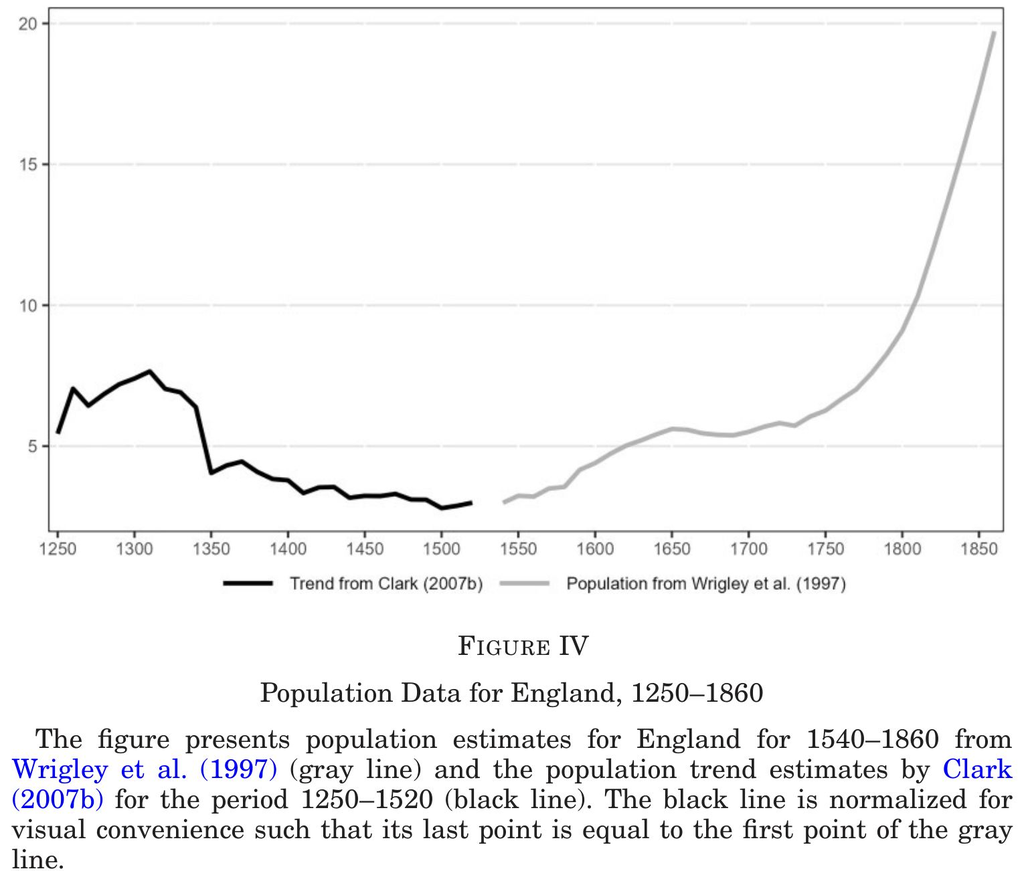

Figure 4: Population

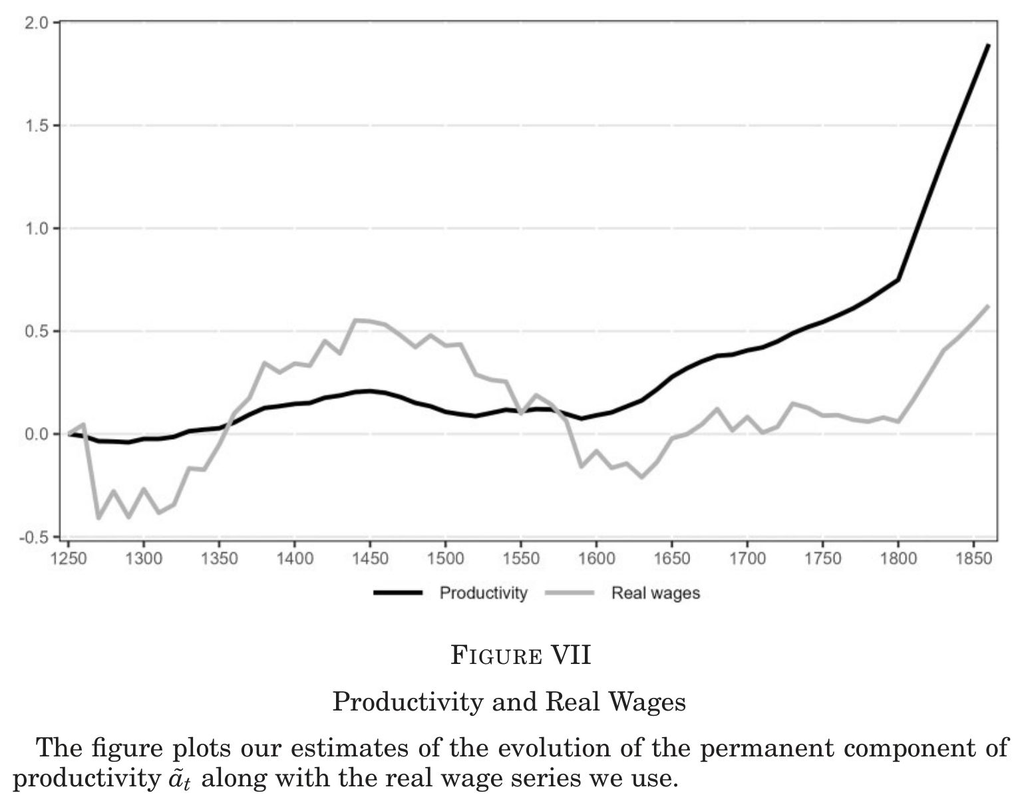

Figure 5: Engels’ Pause, 1730-1800

- No growth (- 1600) → low growth (1600-1810) → high growth (1810-) Figure 3
- Engels’ Pause (no wage growth despite increased TFP growth) is due to population growth, not a decline in labour share Figure 4

### Off

By dating the onset of growth at 1600, below is ruled out:

- Glorious Revolution (1688) (North and Weingast 1989)[^9]
- English Civil War (1642–1651) and Glorious Revolution as joint cause (Acemoglu, Johnson, and Robinson 2005)[^10]
- Post-Glorious Revolution property rights and enclosure reforms (Bogart and Richardson 2011)[^11]
- Industrial Revolution (~1800) as the genesis of growth[^12]
- Capital capturing the gains from technical change as the explanation for Engels’ Pause (Allen 2009a; Acemoglu and Restrepo 2019)[^13]

North, Douglass C., and Barry R. Weingast. 1989. “Constitutions and Commitment: The Evolution of Institutions Governing Public Choice in Seventeenth Century England.” *Journal of Economic History* 49: 803–32. https://doi.org/10.1017/S0022050700009451.

<sup>9</sup> North and Weingast argue that the post-GR power-sharing arrangement among Parliament, the Crown, and the common law courts secured property rights and rule of law, laying the foundation for growth. Ruled out as the *onset*: productivity already rose 34% from 1600 to 1680—roughly a century before 1688.

Acemoglu, Daron, Simon Johnson, and James Robinson. 2005. “The Rise of Europe: Atlantic Trade, Institutional Change, and Economic Growth.” *American Economic Review* 95: 546–79. https://doi.org/10.1257/0002828054201305.

Bogart, Dan, and Gary Richardson. 2011. “Property Rights and Parliament in Industrializing Britain.” *Journal of Law and Economics* 54: 241–74. https://doi.org/10.1086/652901.

<sup>11</sup> Bogart and Richardson stress the post-GR regime’s reorganization of property rights through enclosures, statutory authority acts, and estate acts. Ruled out as the *onset*; the authors note these reforms may have helped *sustain* growth already underway.

———. 2009a. “Engels’ Pause: Technical Change, Capital Accumulation, and Inequality in the British Industrial Revolution.” *Explorations in Economic History* 46: 418–35. https://doi.org/10.1016/j.eeh.2009.04.004.

Acemoglu, Daron, and Pascual Restrepo. 2019. “Artificial Intelligence, Automation, and Work.” In *The Economics of Artificial Intelligence: An Agenda*, edited by Ajay Agrawal, Joshua Gans, and Avi Goldfarb, 197–236. Chicago: University of Chicago Press.

<sup>13</sup> The standard view of stagnant real wages in the late eighteenth century is that the fruits of technical change accrued to capital rather than labor—an idea with modern resonance in discussions of automation and AI. BNS instead attribute Engels’ Pause to rapid population growth exerting Malthusian downward pressure on the marginal product of labor.

### Still on

Corroborating (external data independently confirm the timing)

- Onset of structural transformation away from agriculture (Wallis, Colson, and Chilosi 2018)[^14]

Wallis, Patrick, Justin Colson, and David Chilosi. 2018. “Structural Change and Economic Growth in the British Economy Before the Industrial Revolution, 1500–1800.” *Journal of Economic History* 78: 862–903. https://doi.org/10.1017/S0022050718000396.

<sup>14</sup> Wallis, Colson, and Chilosi estimate that the share of workers in agriculture began a sustained fall around 1600 after being stable in the sixteenth century, and that labour productivity in agriculture, industry, and services all started rising around 1600. The paper calls this alignment “lines up well.”

Consistent (timing of historical events aligns with 1600)

- Dissolution of the English monasteries and land-market shock (Heldring, Robinson, and Vollmer 2021)[^15]
- Rise of the yeoman class and gradual expansion of property rights (Allen 1992)[^16]
- Atlantic trade, colonisation, and London’s urbanisation[^17]
- Printing press and rising literacy (Dittmar 2011)[^18]
- Marxist view: economic change propels political change (Marx 1932; Marx and Engels 2008)[^19]

Heldring, Leander, James A. Robinson, and Sebastian Vollmer. 2021. “The Long-Run Impact of the Dissolution of the English Monasteries.” *Quarterly Journal of Economics* 136: 2093–2145. https://doi.org/10.1093/qje/qjab030.

<sup>15</sup> Henry VIII’s confiscation of monastic lands (1530s–1540s) was a large shock to land ownership and the land market. England also became a destination for skilled Protestant immigrants fleeing persecution on the continent. The paper calls the Reformation “an obvious candidate.”

Allen, Robert C. 1992. *Enclosure and the Yeoman*. Oxford: Oxford University Press.

<sup>16</sup> Allen argues that a 600-year process from the Norman Conquest culminated in the sixteenth century with the yeoman class holding a substantial proprietary interest in land, and hence an incentive to innovate. The paper notes this “lines up reasonably well” with the estimated onset.

<sup>17</sup> The British East India Company was founded in 1600; the Virginia Company established its first permanent North American settlement in 1607. London’s population exploded from 55,000 (1520) to 475,000 (1670), driven by rapid expansion of international trade in woollens, intercontinental commerce, and privateering. Timing coincides directly with the 1600 break.

Dittmar, Jeremiah E. 2011. “Information Technology and Economic Change: The Impact of the Printing Press.” *Quarterly Journal of Economics* 126: 1133–72. https://doi.org/10.1093/qje/qjr035.

<sup>18</sup> Spread of movable-type printing after 1450 produced large literacy gains in England in the sixteenth and seventeenth centuries and a sharp fall in book prices. Dittmar finds that cities exposed to printing grew substantially faster than otherwise comparable cities. Timing is consistent with the 1600 onset.

Marx, Karl. 1932. *Capital. A Critique of Political Economy, Volume 1*. Chicago: Charles H. Kerr & Company.

Marx, Karl, and Friedrich Engels. 2008. *The Communist Manifesto*. London: Pluto Press.

<sup>19</sup> Marx stressed the transition from feudalism to capitalism—expulsion of peasants through enclosure creating a proletariat available for wage labour, ultimately driving political revolution. The finding that growth preceded both the Civil War and the Glorious Revolution is consistent with economic transformation causing political change rather than the reverse. The paper says this “lends support” to the Marxist view.

Consistent but timing hard to pin down

- Culture of progress and bourgeois values (Mokyr 2009, 2016; McCloskey 2006)[^20]
- Protestant ethic and Puritanism (Weber 1904; Tawney 1926)[^21]

Mokyr, Joel. 2009. *The Enlightened Economy: The Economic History of Britain, 1700–1850*. New Haven, CT: Yale University Press.

———. 2016. *A Culture of Growth: The Origins of the Modern Economy*. Princeton, NJ: Princeton University Press.

McCloskey, Deirdre. 2006. *The Bourgeois Virtues: Ethics for an Age of Commerce*. Chicago: University of Chicago Press. https://doi.org/10.7208/chicago/9780226556673.001.0001.

<sup>20</sup> Mokyr and McCloskey argue that the crucial change was the emergence of a science-based culture holding that human conditions can be improved through rational thought. The paper notes the timing “lines up reasonably well” but acknowledges it is “not straightforward to pinpoint precisely what these theories imply about the timing of the onset of growth.”

Weber, Max. 1904. “The Protestant Ethic and the ’Spirit’ of Capitalism.” *Archiv Für Sozialwissenschaft Und Sozialpolitik* 20: 1–54.

Tawney, R. H. 1926. *Religion and the Rise of Capitalism*. New York: Routledge.

<sup>21</sup> Weber and Tawney link the Protestant Reformation to attitudes favouring diligence, thrift, and commercial activity. The paper applies the same caveat as for culture-of-progress theories: timing is reasonably consistent but imprecise.

Complementary (explains the character of the Industrial Revolution, not its onset)

- High-wage, cheap-coal theory of the Industrial Revolution (Allen 2009b)[^22]

———. 2009b. *The British Industrial Revolution in Global Perspective*. Cambridge: Cambridge University Press.

<sup>22</sup> Allen argues that the IR took the particular form it did—labour-saving textile machinery, steam engines—because growth in the seventeenth century had already pushed English wages high relative to coal prices, making it uniquely profitable to invent such technologies. The paper notes this “helps explain how growth was sustained and the particular direction it took” but does not point to it as the genesis of growth.

## Modest growth after the onset

Efforescence: Sustained growth prior to Industrial Revolution

- Ancient Greece, ancient Rome, Song China (宋960–1279), Islamic golden age, golden age of Holland
- Often used as evidence against a Malthusian model
- Similar to the Malthusian model of England 1600-1810

## Post Industrial Revolution

This is more of a secondary research question, but a very insightful finding

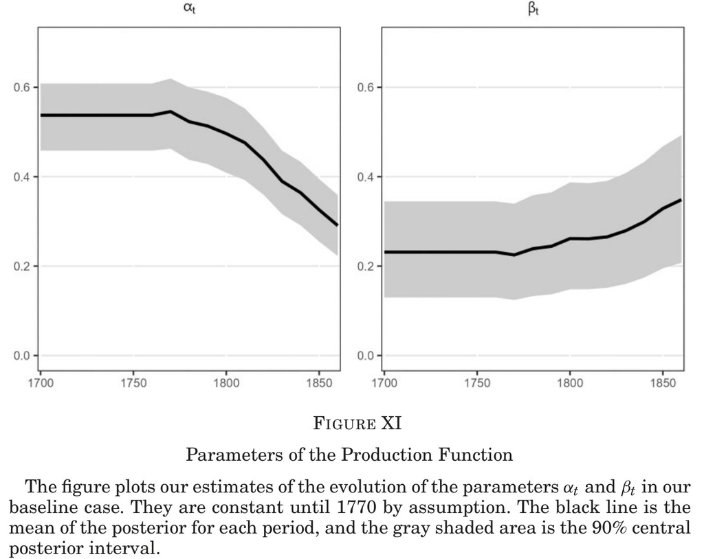

Table 2: Steam engine took over

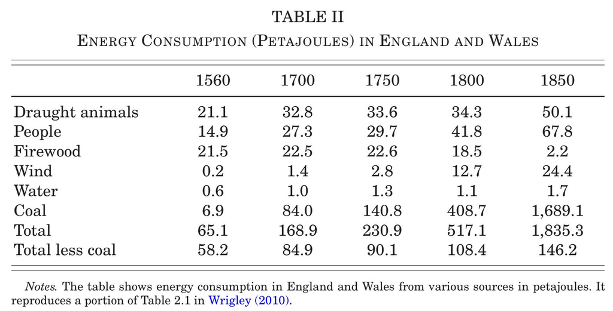

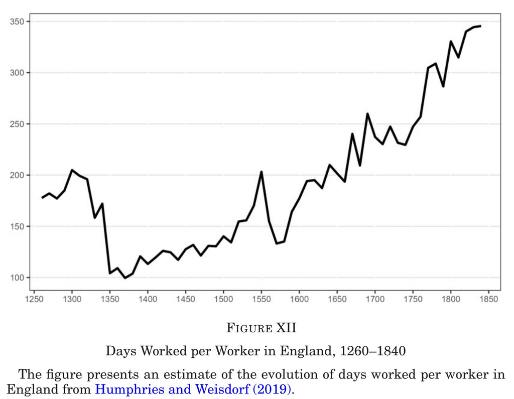

Figure 7: Days worked doubled

- Decline in importance of land in production (Figure 6)
- (Not a result): Steam engine took over after 1810 (Table 2)
- (Not a result): Days worked increased (Figure 7)

By easing the fixed land constraint, people started to work longer and production increased with more labour and capital

# 感想

- 世界で経済発展が開始した年代を特定した影響力のある論文
- 他人のデータを使いつつ、単純なモデルと組み合わせることで新たな発見を提供したお手軽論文かと思って読み始めた
- 読み進めると、Bayesianを使う仕掛けをそこら中に仕込んだ手の込んだ論文だと分かった
- 産業革命の解釈: 経済活動を土地制約から開放したこと
- 蒸気機関さまさま
- Vent for surplus: 余剰だった労働が不足になった
- T=61、仕方ないが…
- 今後もこの分野は、推計方法の改善よりもデータ構築の方が貢献度は高い